# heart-rate-visualization

Adam Resnick

Created 8/17/2018, Uploaded 5/30/2020

## Project Overview

For this project, I wanted to look at workout data collected from my Fitbit. I investigated the relationship between HR and speed, as created some cool visualizations.

### Reading in data

```r
wo1RAW <-read.csv("2018-08-07 - 0629.csv", header=TRUE, stringsAsFactors = FALSE)
wo2RAW <-read.csv("2018-08-09 - 1958.csv", header=TRUE, stringsAsFactors = FALSE)
wo3RAW <-read.csv("2018-08-13 - 1705.csv", header=TRUE, stringsAsFactors = FALSE)
```

### Loading Libraries

I used the tidyverse library, which includes ggplot, dplyr, and more top R libraries.

```r
library(tidyverse)
```

### Data Formatting, Data Cleaning, Speed Calculation

After reading in the datasets, I got rid of the columns I wasn’t interested in, leaving the GPS data, heartrate, and distance. I then formatted the time and elliminated any rows with missing data.

```r
wo1 <- wo1RAW

#deleting unnecessary columns in wo1
wo1$Sport <- NULL; wo1$ï..Sport <- NULL; wo1$ns1.TriggerMethod <- NULL; wo1$ns1.Name <- NULL; wo1$ns1.TotalTimeSeconds <- NULL
wo1$ns1. <- NULL; wo1$ns1.DistanceMeters <- NULL; wo1$ns1.UnitId <- NULL; wo1$ns1.ProductID <- NULL
wo1$ns1.Calories <- NULL; wo1$ns1.Id <- NULL; wo1$StartTime <- NULL; wo1$ns1.Intensity <- NULL

#renaming columns in wo1
names(wo1)[1] <- "DateTime"; names(wo1)[2] <- "Latitude"; names(wo1)[3] <- "Longitude"; names(wo1)[4] <- "Altitude"
names(wo1)[5] <- "Distance"; names(wo1)[6] <- "HR"

#Formatting time
wo1$DateTime <- sub(pattern="T", replace=" ", wo1$DateTime)
wo1$DateTime <- sub(pattern=".00.*", replace="", wo1$DateTime)
wo1$DateTime <- as.POSIXct(wo1$DateTime, format = "%Y-%m-%d %H:%M:%S")
wo1$Date <- sub(pattern=" .*", replace="", wo1$DateTime)
wo1$Date <- as.Date(wo1$Date)
wo1$Time <- sub(pattern=".* ", replace="", wo1$DateTime)

#Eliminating rows with any missing data
wo1 <- wo1[complete.cases(wo1),]
```

I calculated speed using the distance and time variables. I then got rid of any junk data, such as negative speeds and speeds inconsistent with the workout I was doing (AKA: speeds over 15mph).

```r
#Adding Speed
wo1$Speed <- rep(NA, length(wo1$DateTime))
for(i in 2:length(wo1$DateTime)){
  wo1$Speed[i] <- (wo1$Distance[i]-wo1$Distance[i-1])*0.0006213712/(as.numeric((wo1$DateTime[i]-wo1$DateTime[i-1]))/3600)
}

#Cleaning up dataframe
wo1 <- wo1[wo1$Speed>0,]        #Gets rid of rows with negative speed (not possible)
wo1 <- wo1[wo1$Speed<15,]        #Gets rid of rows with unrealistic speed
wo1 <- wo1[2:length(wo1$DateTime),]
```

### Plotting data

I chose to create a couple plots for visualization purposes and save them as .png files.

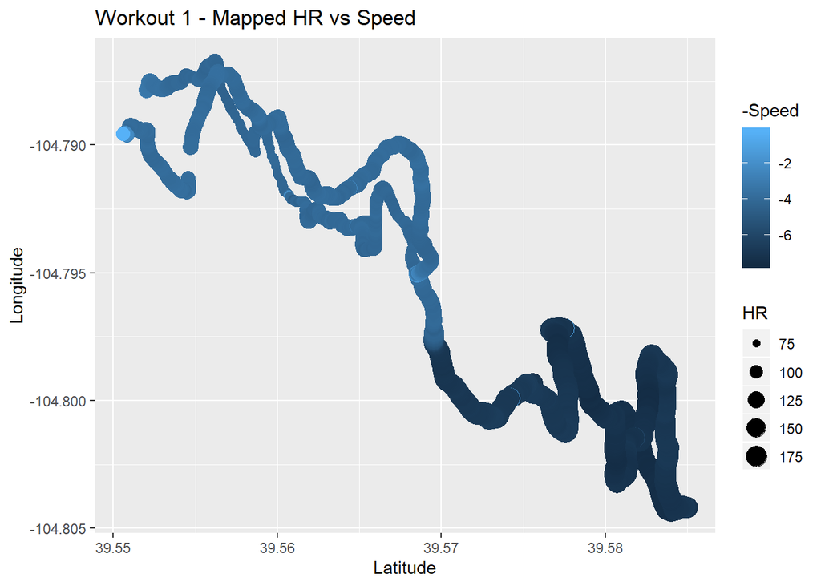

```r
#Plotting Lat, Long, Speed, and HR for Workout 1
ggplot(data=wo1, aes(x=Latitude, y=Longitude, color=-Speed, size=HR))+geom_point()+ggtitle("Workout 1 - Mapped HR vs Speed")
```

[figure not shown]

```r
ggsave("Workout1_HRSpeed.png", width = 6, height = 6, units = "in",
       dpi = 300)
```

### Regression Analysis

Finally, I performed a regression analysis on each of the workout’s HR vs Speed. I also compared log(HR) vs Speed and HR vs log(Speed), but straight HR vs Speed produced the highest R-squared values for each of the workouts.

#### Workout 1

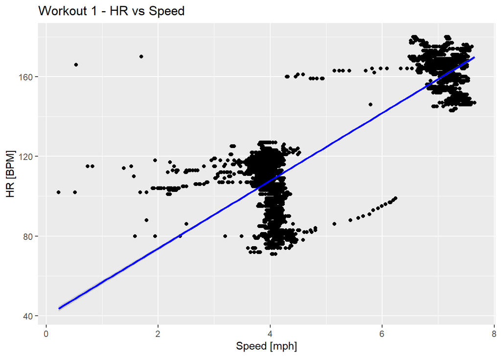

```r
ggplot(data=wo1, aes(x=Speed, y=HR))+geom_point()+geom_smooth(method="lm", color="blue")+xlab("Speed [mph]")+ylab("HR [BPM]")+ggtitle("Workout 1 - HR vs Speed")
```

```r
mod.1 <- lm(formula=HR~Speed, data=wo1)
summary(mod.1)
```

```
##
## Call:
## lm(formula = HR ~ Speed, data = wo1)
##
## Residuals:
##     Min      1Q  Median      3Q     Max
## -47.332  -8.811   4.566  10.106 117.043
##
## Coefficients:
##             Estimate Std. Error t value Pr(>|t|)
## (Intercept)  39.8376     0.6952    57.3   <2e-16 ***
## Speed        16.9866     0.1327   128.0   <2e-16 ***
## ---
## Signif. codes:  0 '***' 0.001 '**' 0.01 '*' 0.05 '.' 0.1 ' ' 1
##
## Residual standard error: 15.33 on 5659 degrees of freedom
## Multiple R-squared:  0.7433, Adjusted R-squared:  0.7432
## F-statistic: 1.638e+04 on 1 and 5659 DF,  p-value: < 2.2e-16
```

#### Workout 2

You’ll notice that Workout 2 has a very low R-squared value. This is a result of very little variance of speed (I walked all of it) and thus little variance in HR. While the overall trend mirrors that of the other two workouts, the lack of any real variance in speed makes for a poor training set. It’s included here purely for the sake of discussion.

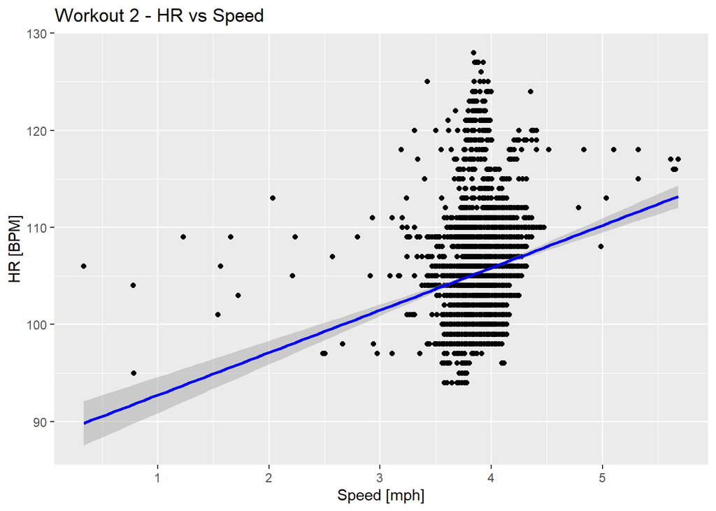

```r
ggplot(data=wo2, aes(x=Speed, y=HR))+geom_point()+geom_smooth(method="lm", color="blue")+xlab("Speed [mph]")+ylab("HR [BPM]")+ggtitle("Workout 2 - HR vs Speed")
```

```r
mod.2 <- lm(formula=HR~Speed, data=wo2)
summary(mod.2)
```

```
##
## Call:
## lm(formula = HR ~ Speed, data = wo2)
##
## Residuals:
##      Min       1Q   Median       3Q      Max
## -10.8863  -3.6458  -0.5705   2.7596  22.8400
##
## Coefficients:
##             Estimate Std. Error t value Pr(>|t|)
## (Intercept)  88.3661     1.2742   69.35   <2e-16 ***
## Speed         4.3699     0.3267   13.38   <2e-16 ***
## ---
## Signif. codes:  0 '***' 0.001 '**' 0.01 '*' 0.05 '.' 0.1 ' ' 1
##
## Residual standard error: 5.072 on 4476 degrees of freedom
## Multiple R-squared:  0.03843,    Adjusted R-squared:  0.03821
## F-statistic: 178.9 on 1 and 4476 DF,  p-value: < 2.2e-16
```

#### Workout 3

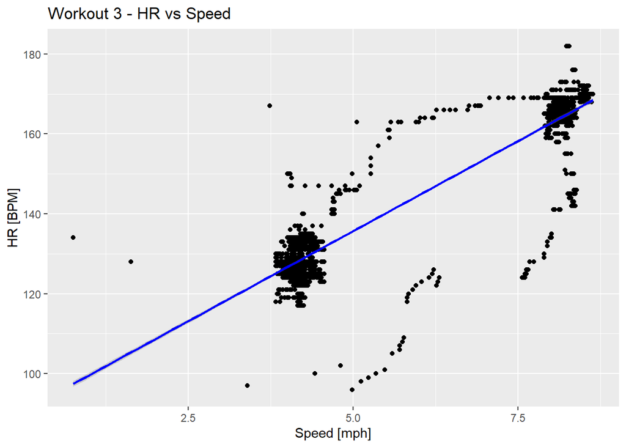

```r
ggplot(data=wo3, aes(x=Speed, y=HR))+geom_point()+geom_smooth(method="lm", color="blue")+xlab("Speed [mph]")+ylab("HR [BPM]")+ggtitle("Workout 3 - HR vs Speed")
```

```r
mod.3 <- lm(formula=HR~Speed, data=wo3)
summary(mod.3)
```

```
##
## Call:
## lm(formula = HR ~ Speed, data = wo3)
##
## Residuals:
##     Min      1Q  Median      3Q     Max
## -39.579  -2.103   0.562   3.571  42.722
##
## Coefficients:
##             Estimate Std. Error t value Pr(>|t|)
## (Intercept) 90.57544    0.41827   216.5   <2e-16 ***
## Speed        9.02177    0.07182   125.6   <2e-16 ***
## ---
## Signif. codes:  0 '***' 0.001 '**' 0.01 '*' 0.05 '.' 0.1 ' ' 1
##
## Residual standard error: 6.811 on 2569 degrees of freedom
## Multiple R-squared:   0.86,  Adjusted R-squared:  0.8599
## F-statistic: 1.578e+04 on 1 and 2569 DF,  p-value: < 2.2e-16
```

### Summary

This was a fun project to work on and reinforced the basic R concepts from this class. Now that I have the data cleaning operations set up, I can upload future workout data quite easily.

### Further Work

I would investigate ways to replace any missing data. While this is not necessary for the analysis, it would improve the readibility of the plots that include latitude and longitude.

Additionally, I plan on recording data for more speeds, not just ~4mph and ~7.5mph. Ideally, I would start out at 4mph and slowly increase my speed to ~8mph. This would give a better understanding of how HR truly differs with speed. I’d be curious to see if the relationship would be linear or if it would be better fit by something polynomial.